# Dialectal Variation in Interpretation of an Auditory Illusion

9/9/2019

## Introduction

**Dialectal Variation in Interpretation of an Auditory Illusion: Or, Laurel vs. Yanny**

In May 2018, Instagram influencer Chloe Feldman posted a computer-edited audio clip which became a viral topic of debate on social media. She asked listeners to vote on whether they heard “Laurel” or “Yanny” after listening to the clip. Some listeners definitively heard “Laurel”, while others distinctly heard “Yanny” – and so the debate began.

[Listen here](https://www.nytimes.com/interactive/2018/05/16/upshot/audio-clip-yanny-laurel-debate.html)

[See Tweets](https://twitter.com/search?q=%23yannyvslaurel&src=typed_query&f=top)

## Hypothesizing in the Media

Several well-known linguists and psychologists were interviewed about the phenomenon.

- Older listeners lack the ability to hear higher pitches, which could influence the choice between Laurel and Yanny ([Alais](https://www.theguardian.com/technology/2018/may/16/yanny-or-laurel-sound-illusion-sets-off-ear-splitting-arguments))
- Personal history could play a role in what you hear ( [McDermott](https://www.theguardian.com/technology/2018/may/16/yanny-or-laurel-sound-illusion-sets-off-ear-splitting-arguments)).
- The spectrogram is not typical of either Laurel or Yanny ([Sanker](https://www.theatlantic.com/technology/archive/2018/05/dont-rest-on-your-laurels/560483/))
- The altered sound clip has higher noise and higher frequencies laid over a typical sound.

## Hypothesizing in the Media

Several well-known linguists and psychologists were interviewed about the phenomenon.

- Older listeners lack the ability to hear higher pitches, which could influence the choice between Laurel and Yanny ([Alais](https://www.theguardian.com/technology/2018/may/16/yanny-or-laurel-sound-illusion-sets-off-ear-splitting-arguments))
- Personal history could play a role in what you hear ( [McDermott](https://www.theguardian.com/technology/2018/may/16/yanny-or-laurel-sound-illusion-sets-off-ear-splitting-arguments)).
- The spectrogram is not typical of either Laurel or Yanny ([Sanker](https://www.theguardian.com/technology/2018/may/16/yanny-or-laurel-sound-illusion-sets-off-ear-splitting-arguments))

Very interesting: [Adjusting the pitch can change what word you hear](https://www.nytimes.com/interactive/2018/05/16/upshot/audio-clip-yanny-laurel-debate.html)

## Hypothesizing in the Media

Several linguists and psychologists were interviewed about the phenomenon.

- Older listeners lack the ability to hear higher pitches, which could influence the choice between Laurel and Yanny ([Alais](https://www.theguardian.com/technology/2018/may/16/yanny-or-laurel-sound-illusion-sets-off-ear-splitting-arguments))
- Personal history could play a role in what you hear ( [McDermott](https://www.theguardian.com/technology/2018/may/16/yanny-or-laurel-sound-illusion-sets-off-ear-splitting-arguments)).
- The spectrogram is not typical of either Laurel or Yanny ([Sanker](https://www.theguardian.com/technology/2018/may/16/yanny-or-laurel-sound-illusion-sets-off-ear-splitting-arguments))

**Question: Does your regional dialect influenct your likelihood of hearing Laurel vs. Yanny?**

## Hypothesis

Different dialects have different proportions of Laurel vs. Yanny.

More specifically: Geographic location, as a proxy for dialect, shows a difference in choice of Laurel vs.Yanny.

## Method

- Get a large number of Tweets about Laurel and Yanny
- Code them as team Laurel or team Yanny
- Code them by geographic location of the Tweeter
- Test location as related to word choice

## Method, Refined

- Use the twitteR package to automatically retrieve tweets via the Twitter API

## Method, Refined

- Use the twitteR package to automatically retrieve tweets via the Twitter API
- Code each tweet as Laurel or Yanny based upon “majority rules”

## Method, Refined

- Use the twitteR package to automatically retrieve tweets via the Twitter API
- Code each tweet as Laurel or Yanny based upon “majority rules”
- Use user-provided profile information stating geographic location. This information is usually not provided by users, and so it will reduce the sample size.

## Method, Refined

- Use the twitteR package to automatically retrieve tweets via the Twitter API
- Code each tweet as Laurel or Yanny based upon “majority rules”
- Use user-provided profile information stating geographic location. This information is usually not provided by users, and so it will reduce the sample size.
- De-dupe the dataset to remove duplicate posters. Take the first tweet from users who tweeted multiple times.

## Method, Refined

- Use the twitteR package to automatically retrieve tweets via the Twitter API
- Code each tweet as Laurel or Yanny based upon “majority rules”
- Use user-provided profile information stating geographic location. This information is usually not provided by users, and so it will reduce the sample size.
- De-dupe the dataset to remove duplicate posters. Take the first tweet from users who tweeted multiple times.
- Merge the geo-coded dataset of Tweets with census locations, to code by census region.

## Method, In Practice

- 37,064 unique tweets containing the word “yanny” or the word “laurel” (or both) were gathered via the Twitter API using the [twitteR](https://cran.r-project.org/web/packages/twitteR/twitteR.pdf) package.
- These tweets included retweets, since it was assumed that retweeting also signified contributing an opinion to the debate.
- From these tweets, the Twitter API was used again to retrieve the location information (if any) listed in the bio of each relevent accounts.

## Method, In Practice

- After gathering the data, a “winner”" was calculated, by tweet, by tallying “laurel” mentions vs. “yanny” mentions and taking the highest tally. This winner formed the metric of a speaker’s choice.
- This approach assumed that a speaker would mention more often the form that they prefer – for example:

## Method, In Practice

- After gathering the data, a “winner”" was calculated, by tweet, by tallying “laurel” mentions vs. “yanny” mentions and taking the highest tally. This winner formed the metric of a speaker’s choice.
- This approach assumed that a speaker would mention more often the form that they prefer – for example:

*When I say yanny… do you hear laurel?" - Coworker. Bruhhhh what? #laurel*

## Method, In Practice

- After gathering the data, a “winner”" was calculated, by tweet, by tallying “laurel” mentions vs. “yanny” mentions and taking the highest tally. This winner formed the metric of a speaker’s choice.
- This approach assumed that a speaker would mention more often the form that they prefer – for example:

*This may cause divorce. My husband hears it wrong. #Laurel https://t.co/FTmCsZoY8i*

## Method, In Practice

- After gathering the data, a “winner”" was calculated, by tweet, by tallying “laurel” mentions vs. “yanny” mentions and taking the highest tally. This winner formed the metric of a speaker’s choice.
- This approach assumed that a speaker would mention more often the form that they prefer – for example:

*Transervice is team Yanny… what about you Yanny or Laurel, what do you hear? https://t.co/lxG6p8g01I*

## Method, In Practice

- After gathering the data, a “winner”" was calculated, by tweet, by tallying “laurel” mentions vs. “yanny” mentions and taking the highest tally. This winner formed the metric of a speaker’s choice.
- This approach assumed that a speaker would mention more often the form that they prefer – for example:

*I stg this is causing a war in my family. 3/5 hear #yanny while 2/5 hears #laurel I’m 100% team Yanny https://t.co/PG7twEhLbB*

## Method, In Practice

- After gathering the data, a “winner”" was calculated, by tweet, by tallying “laurel” mentions vs. “yanny” mentions and taking the highest tally. This winner formed the metric of a speaker’s choice.
- This approach assumed that a speaker would mention more often the form that they prefer – for example:

*RT @LoriLoughlin: I hear Yanny. #yannyvslaurel #Yanny https://t.co/fUo9jDDqhp*

## Keep in Mind…

- After cutting down to users who provided their location, n = 6424.
- I used the free Twitter API, which uses a “Twitter recommended” result, rather than an exhaustive result. This could bias the data.
- I sampled from Twitter, so the population of interest is only Twitter users – and moreover, Twitter users who volunteered their geolocation in their profile. This could again bias the data, and results may not generalize to U.S. or global populations.
- Dialects are much more granular than census regions. It is necessary to aggregate at the census region level to achieve sample size, but this is a rough aggregate approximation for dialects.

## Results

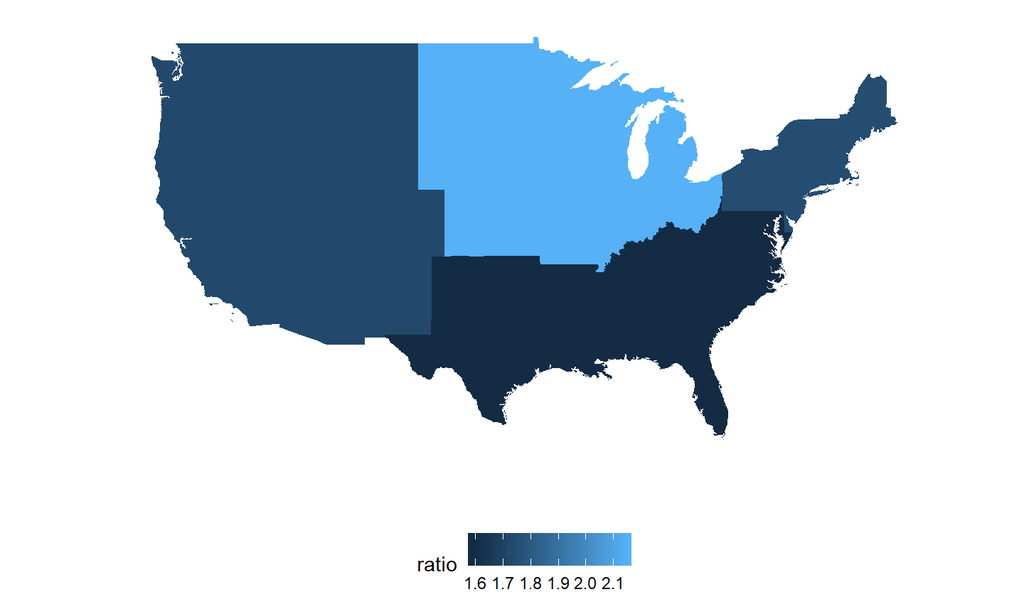

## Results

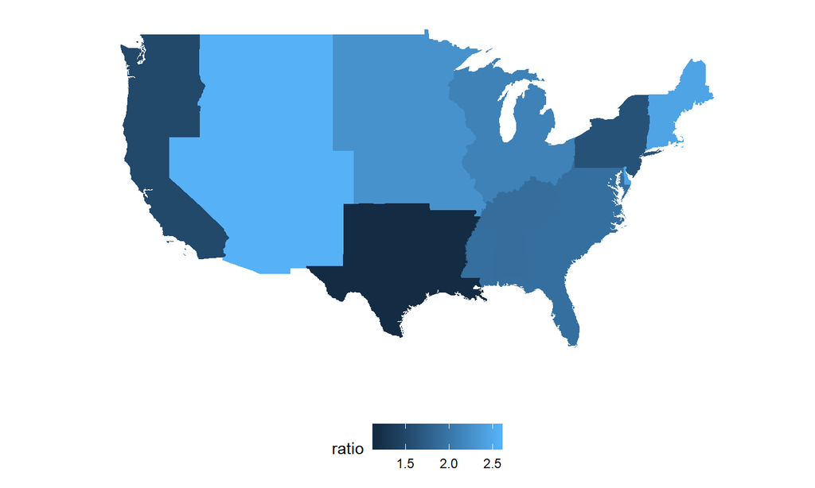

## Results

When mapped by census region, the Laurel/Yanny preference does seem to have a geographic component.

## Analysis

A chi-squared test was performed using the average of the Laurel/Yanny proportions to establish an expected value for Laurel choices (p < 0.05).

## Analysis

- Could you even predict choice by census region?
- A logistic regression model predicting choosing Yanny from census region found that none of the regions significantly predicted Yanny choice.
- It is worth keeping in mind that there are *many* potential factors that would go into this choice, though.

## Conclusion

Based upon one experiment using very noisy social media data – it does look like a tentative difference exists by location when looking at Laurel-Yanny preference. The relationship was not strong enough to build a preditive model.

Time for a more balanced and complete experiment?